# 2023 MLB Player Analysis

```r
stats <- read.csv("mlb_stats_2023clean.csv")
sb <- read.csv("sbdata.csv")

stats = merge(stats, sb, by.x=c("first_name", "last_name"), by.y=c("first_name", "last_name"))
```

```r
all <- read.csv("2022_2023all.csv")
```

```r
colnames(stats)[4] <- "age"
colnames(all)[4] <- "age"
```

```r
by_age <- all %>%
  group_by(age) %>%
  summarise(total_ab=sum(ab),
             total_hits=sum(hit))


by_age$ageBA <- by_age$total_hits / by_age$total_ab
by_age$norm_hits <- log(by_age$total_hits)
by_age$norm_ba <- log(by_age$ageBA)
by_age$norm_hits_x_ba <- by_age$norm_hits * by_age$ageBA


final_stats <- left_join(stats, by_age, by = "age")
final_stats$k_pct <- (final_stats$strikeout / final_stats$pa) * 100

final_stats = subset(final_stats, select = -c(total_ab,total_hits, norm_hits, norm_ba) )

final_stats$sb_pa <- final_stats$sb / final_stats$pa
```

```r
age_val <- by_age %>%
  arrange(desc(age))

age_val = subset(age_val, select = -c(norm_ba) )


kable(age_val, caption = "Every Age Combined Statistics 2022-2023")
```

Every Age Combined Statistics 2022-2023

| age | total_ab | total_hits | ageBA | norm_hits | norm_hits_x_ba |
| --- | --- | --- | --- | --- | --- |
| 42 | 450 | 118 | 0.2622222 | 4.770685 | 1.2509795 |
| 41 | 448 | 105 | 0.2343750 | 4.653960 | 1.0907720 |
| 40 | 334 | 86 | 0.2574850 | 4.454347 | 1.1469277 |
| 39 | 1265 | 287 | 0.2268775 | 5.659482 | 1.2840090 |
| 38 | 1926 | 442 | 0.2294912 | 6.091310 | 1.3979019 |
| 37 | 1750 | 394 | 0.2251429 | 5.976351 | 1.3455327 |
| 36 | 3497 | 804 | 0.2299114 | 6.689599 | 1.5380148 |
| 35 | 6543 | 1642 | 0.2509552 | 7.403670 | 1.8579897 |
| 34 | 9237 | 2298 | 0.2487821 | 7.739795 | 1.9255221 |
| 33 | 13746 | 3338 | 0.2428343 | 8.113127 | 1.9701454 |
| 32 | 20086 | 4879 | 0.2429055 | 8.492696 | 2.0629225 |
| 31 | 23855 | 5823 | 0.2440998 | 8.669571 | 2.1162403 |
| 30 | 27935 | 6909 | 0.2473241 | 8.840580 | 2.1864889 |
| 29 | 28358 | 7022 | 0.2476197 | 8.856803 | 2.1931192 |
| 28 | 35726 | 8713 | 0.2438840 | 9.072571 | 2.2126551 |
| 27 | 34246 | 8316 | 0.2428313 | 9.025937 | 2.1917797 |
| 26 | 29394 | 7357 | 0.2502892 | 8.903408 | 2.2284265 |
| 25 | 32246 | 8108 | 0.2514420 | 9.000606 | 2.2631309 |
| 24 | 24154 | 5946 | 0.2461704 | 8.690474 | 2.1393375 |
| 23 | 18010 | 4311 | 0.2393670 | 8.368925 | 2.0032447 |
| 22 | 9259 | 2275 | 0.2457069 | 7.729735 | 1.8992491 |
| 21 | 4871 | 1242 | 0.2549784 | 7.124478 | 1.8165884 |
| 20 | 169 | 40 | 0.2366864 | 3.688880 | 0.8731076 |
| 19 | 34 | 8 | 0.2352941 | 2.079442 | 0.4892804 |

Create a model to predict the total number of hits for a player in the season.

```r
library(mgcv)
mod <- lm(hit ~ ab + launch_angle_avg + sweet_spot_percent + exit_velocity_avg + k_pct +sb_pa, data=final_stats)

#mod <- lm(hit ~ ab + launch_angle_avg + sweet_spot_percent, data=final_stats)
#mod <- lm(hit ~ ., data = final_stats)

summary(mod)
```

```
##
## Call:
## lm(formula = hit ~ ab + launch_angle_avg + sweet_spot_percent +
##     exit_velocity_avg + k_pct + sb_pa, data = final_stats)
##
## Residuals:
##      Min       1Q   Median       3Q      Max
## -30.6138  -5.4381  -0.3194   5.0883  31.0778
##
## Coefficients:
##                      Estimate Std. Error t value Pr(>|t|)
## (Intercept)        -1.810e+02  2.130e+01  -8.500 5.36e-16 ***
## ab                  2.647e-01  3.927e-03  67.406  < 2e-16 ***
## launch_angle_avg   -5.443e-01  1.059e-01  -5.139 4.58e-07 ***
## sweet_spot_percent  1.109e+00  1.237e-01   8.969  < 2e-16 ***
## exit_velocity_avg   1.833e+00  2.457e-01   7.462 6.68e-13 ***
## k_pct              -8.467e-01  8.654e-02  -9.785  < 2e-16 ***
## sb_pa               1.027e+02  2.346e+01   4.379 1.57e-05 ***
## ---
## Signif. codes:  0 '***' 0.001 '**' 0.01 '*' 0.05 '.' 0.1 ' ' 1
##
## Residual standard error: 8.454 on 354 degrees of freedom
## Multiple R-squared:  0.955,  Adjusted R-squared:  0.9543
## F-statistic:  1253 on 6 and 354 DF,  p-value: < 2.2e-16
```

```r
preds <- predict(mod, final_stats)
final_stats$xHits <- preds
```

Find the difference between the predicted value and the actual value.

```r
final_stats$hit_diff <- final_stats$xHits - final_stats$hit
```

I will utilize ggplot here to highlight the predicted number of hits versus the actual number of hits. This graph will show the accuracy of the model from above.

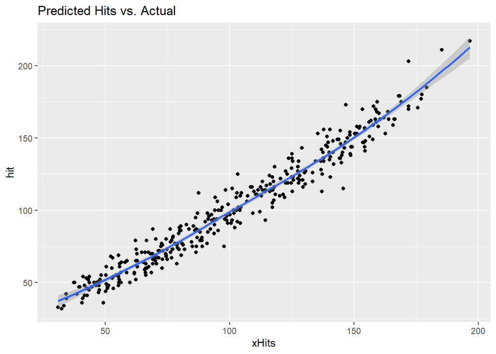

```r
library(dplyr)
final_stats %>%
  ggplot(aes(xHits, hit)) +
  geom_point() +
  geom_smooth() +
  ggtitle('Predicted Hits vs. Actual')
```

We do not need all the columns that are currently in this data set, so I will take out the vast majority of them and create a new data frame which is much easier on the eye.

```r
stats_limit <- final_stats[, c("last_name", "first_name", "age", "ab", "pa", "hit", "batting_avg", "xHits", "hit_diff", "sb", "norm_hits_x_ba", "ageBA")]

#stats_limit <- final_stats %>%
  #select(last_name, first_name, age, ab, pa, hit, batting_avg,
         #xHits, hit_diff)
```

Since the number of at-bats varies for every player, I will divide the difference from expected hits and actual hits by the total number of at-bats this past season. From there, I will normalize the values on a 0 to 1 scale. The values after applying the division are quite small, and this will allow the analysis to go much smoother. The equation will look like the following: $y = norm(\frac{xH - H}{AB})$

```r
stats_limit$hitDiffperAB <- stats_limit$hit_diff / stats_limit$ab


min <- min(stats_limit$hitDiffperAB)
max <- max(stats_limit$hitDiffperAB)

stats_limit$normDiffperAB <- (stats_limit$hitDiffperAB - min)/(max - min)
```

```r
top10all <- stats_limit %>%
  arrange(desc(Normalized)) %>%
  slice(1:10)

top10all = subset(top10all, select = -c(SB, Normalized) )


bottom10all <- stats_limit %>%
  arrange(Normalized) %>%
  slice(1:10)

bottom10all = subset(bottom10all, select = -c(SB, Normalized) )
```

```r
kable(top10all, caption = "Top 10 Players in (Expected Hits - Hits) per AB")
```

Top 10 Players in (Expected Hits - Hits) per AB

| Last | First | Age | AB | PA | H | BA | xHits | xHits - H | Normalized Hits x BA | ageBA | (xHits - H)/AB | xBA | BAdiff |
| --- | --- | --- | --- | --- | --- | --- | --- | --- | --- | --- | --- | --- | --- |
| Smith | Pavin | 27 | 191 | 228 | 36 | 0.188 | 49.25191 | 13.25191 | 2.191780 | 0.2428313 | 0.0693817 | 0.2578634 | 0.0698634 |
| Kemp | Tony | 31 | 359 | 419 | 75 | 0.209 | 97.78865 | 22.78865 | 2.116240 | 0.2440998 | 0.0634781 | 0.2723918 | 0.0633918 |
| Wendle | Joey | 33 | 297 | 318 | 63 | 0.212 | 78.71524 | 15.71524 | 1.970145 | 0.2428343 | 0.0529133 | 0.2650345 | 0.0530345 |
| Schwarber | Kyle | 30 | 585 | 720 | 115 | 0.197 | 145.61377 | 30.61377 | 2.186489 | 0.2473241 | 0.0523312 | 0.2489124 | 0.0519124 |
| Matos | Luis | 21 | 228 | 253 | 57 | 0.250 | 68.53492 | 11.53492 | 1.816588 | 0.2549784 | 0.0505918 | 0.3005918 | 0.0505918 |
| Refsnyder | Rob | 32 | 202 | 243 | 50 | 0.248 | 59.88397 | 9.88397 | 2.062922 | 0.2429055 | 0.0489305 | 0.2964553 | 0.0484553 |
| d’Arnaud | Travis | 34 | 267 | 292 | 60 | 0.225 | 72.79133 | 12.79133 | 1.925522 | 0.2487821 | 0.0479076 | 0.2726267 | 0.0476267 |
| Grisham | Trent | 26 | 469 | 555 | 93 | 0.198 | 114.34020 | 21.34020 | 2.228426 | 0.2502892 | 0.0455015 | 0.2437957 | 0.0457957 |
| Lopez | Nicky | 28 | 225 | 262 | 52 | 0.231 | 62.20579 | 10.20579 | 2.212655 | 0.2438840 | 0.0453590 | 0.2764702 | 0.0454702 |
| Volpe | Anthony | 22 | 541 | 601 | 113 | 0.209 | 136.98577 | 23.98577 | 1.899249 | 0.2457069 | 0.0443360 | 0.2532084 | 0.0442084 |

```r
kable(bottom10all, caption = "Bottom 10 Players in (Expected Hits - Hits) per AB")
```

Bottom 10 Players in (Expected Hits - Hits) per AB

| Last | First | Age | AB | PA | H | BA | xHits | xHits - H | Normalized Hits x BA | ageBA | (xHits - H)/AB | xBA | BAdiff |
| --- | --- | --- | --- | --- | --- | --- | --- | --- | --- | --- | --- | --- | --- |
| Triolo | Jared | 25 | 181 | 209 | 54 | 0.298 | 41.08640 | -12.91360 | 2.263131 | 0.2514420 | -0.0713458 | 0.2269967 | -0.0710033 |
| Altuve | Jose | 33 | 360 | 410 | 112 | 0.311 | 87.48398 | -24.51602 | 1.970145 | 0.2428343 | -0.0681000 | 0.2430111 | -0.0679889 |
| McGuire | Reese | 28 | 187 | 206 | 50 | 0.267 | 37.39629 | -12.60371 | 2.212655 | 0.2438840 | -0.0673995 | 0.1999802 | -0.0670198 |
| Lewis | Royce | 24 | 217 | 239 | 67 | 0.309 | 52.95812 | -14.04188 | 2.139337 | 0.2461704 | -0.0647091 | 0.2440466 | -0.0649534 |
| Hicks | Aaron | 33 | 269 | 312 | 68 | 0.253 | 52.20291 | -15.79709 | 1.970145 | 0.2428343 | -0.0587252 | 0.1940629 | -0.0589371 |
| Moniak | Mickey | 25 | 311 | 323 | 87 | 0.280 | 69.14063 | -17.85937 | 2.263131 | 0.2514420 | -0.0574256 | 0.2223171 | -0.0576829 |
| Ford | Mike | 30 | 219 | 251 | 50 | 0.228 | 37.66849 | -12.33151 | 2.186489 | 0.2473241 | -0.0563083 | 0.1720022 | -0.0559978 |
| Ramirez | Harold | 28 | 400 | 434 | 125 | 0.313 | 103.23295 | -21.76705 | 2.212655 | 0.2438840 | -0.0544176 | 0.2580824 | -0.0549176 |
| Arraez | Luis | 26 | 574 | 617 | 203 | 0.354 | 171.92223 | -31.07777 | 2.228426 | 0.2502892 | -0.0541425 | 0.2995161 | -0.0544839 |
| Duvall | Adam | 34 | 320 | 353 | 79 | 0.247 | 62.09756 | -16.90244 | 1.925522 | 0.2487821 | -0.0528201 | 0.1940549 | -0.0529451 |

```r
young_players <- stats_limit %>%
  filter(Age <= 25)
```

Create a data frame of the top 10 and bottom 10 players in respect to the normalized value stated above.

```r
top10 <- young_players %>%
  arrange(desc(Normalized)) %>%
  slice(1:10)

top10 = subset(top10, select = -c(SB, Normalized) )


bottom10 <- young_players %>%
  arrange(Normalized) %>%
  slice(1:10)

bottom10 = subset(bottom10, select = -c(SB, Normalized) )
```

Below are the top 10 players in normalized expected hits per at-bat. These are the players that missed out on some hits, based on the way they connect with the ball.

```r
kable(top10, caption = "Top 10 Players Under 25 in (Expected Hits - Hits) per AB")
```

| Last | First | Age | AB | PA | H | BA | xHits | xHits - H | Normalized Hits x BA | ageBA | (xHits - H)/AB | xBA | BAdiff |
| --- | --- | --- | --- | --- | --- | --- | --- | --- | --- | --- | --- | --- | --- |
| Matos | Luis | 21 | 228 | 253 | 57 | 0.250 | 68.53492 | 11.534924 | 1.816588 | 0.2549784 | 0.0505918 | 0.3005918 | 0.0505918 |
| Volpe | Anthony | 22 | 541 | 601 | 113 | 0.209 | 136.98577 | 23.985771 | 1.899249 | 0.2457069 | 0.0443360 | 0.2532084 | 0.0442084 |
| Burleson | Alec | 24 | 315 | 347 | 77 | 0.244 | 90.89309 | 13.893085 | 2.139337 | 0.2461704 | 0.0441050 | 0.2885495 | 0.0445495 |
| Pasquantino | Vinnie | 25 | 231 | 260 | 57 | 0.247 | 66.16372 | 9.163722 | 2.263131 | 0.2514420 | 0.0396698 | 0.2864230 | 0.0394230 |
| Turang | Brice | 23 | 404 | 448 | 88 | 0.218 | 102.01502 | 14.015019 | 2.003245 | 0.2393670 | 0.0346906 | 0.2525124 | 0.0345124 |
| Carlson | Dylan | 24 | 219 | 255 | 48 | 0.219 | 55.22283 | 7.222833 | 2.139337 | 0.2461704 | 0.0329810 | 0.2521591 | 0.0331591 |
| Baty | Brett | 23 | 353 | 389 | 75 | 0.212 | 86.61002 | 11.610021 | 2.003245 | 0.2393670 | 0.0328896 | 0.2453542 | 0.0333542 |
| Arias | Gabriel | 23 | 315 | 345 | 66 | 0.210 | 74.86843 | 8.868428 | 2.003245 | 0.2393670 | 0.0281537 | 0.2376775 | 0.0276775 |
| Wiemer Jr. | Joey | 24 | 367 | 410 | 75 | 0.204 | 84.94364 | 9.943635 | 2.139337 | 0.2461704 | 0.0270944 | 0.2314540 | 0.0274540 |
| Massey | Michael | 25 | 428 | 461 | 98 | 0.229 | 109.24853 | 11.248534 | 2.263131 | 0.2514420 | 0.0262816 | 0.2552536 | 0.0262536 |

Below are the bottom 10 players. These results could be due to a handful of reasons. The most reasonable of those is luck-based. For example, these players may have had a handful more bloop singles than the players on the list above. In general, they are not squaring up the ball as much as their batting average numbers from this previous season may appear.

```r
kable(bottom10, caption = "Bottom 10 Players Under 25 in (Expected Hits - Hits) per AB")
```

| Last | First | Age | AB | PA | H | BA | xHits | xHits - H | Normalized Hits x BA | ageBA | (xHits - H)/AB | xBA | BAdiff |
| --- | --- | --- | --- | --- | --- | --- | --- | --- | --- | --- | --- | --- | --- |
| Triolo | Jared | 25 | 181 | 209 | 54 | 0.298 | 41.08640 | -12.913596 | 2.263131 | 0.2514420 | -0.0713458 | 0.2269967 | -0.0710033 |
| Lewis | Royce | 24 | 217 | 239 | 67 | 0.309 | 52.95812 | -14.041879 | 2.139337 | 0.2461704 | -0.0647091 | 0.2440466 | -0.0649534 |
| Moniak | Mickey | 25 | 311 | 323 | 87 | 0.280 | 69.14063 | -17.859375 | 2.263131 | 0.2514420 | -0.0574256 | 0.2223171 | -0.0576829 |
| Wallner | Matt | 25 | 213 | 254 | 53 | 0.249 | 42.34047 | -10.659529 | 2.263131 | 0.2514420 | -0.0500447 | 0.1987816 | -0.0502184 |
| Montero | Elehuris | 24 | 284 | 307 | 69 | 0.243 | 55.26790 | -13.732102 | 2.139337 | 0.2461704 | -0.0483525 | 0.1946053 | -0.0483947 |
| Jones | Nolan | 25 | 367 | 424 | 109 | 0.297 | 94.10823 | -14.891768 | 2.263131 | 0.2514420 | -0.0405770 | 0.2564257 | -0.0405743 |
| Frelick | Sal | 23 | 191 | 223 | 47 | 0.246 | 39.48087 | -7.519131 | 2.003245 | 0.2393670 | -0.0393672 | 0.2067061 | -0.0392939 |
| Peguero | Liover | 22 | 198 | 213 | 47 | 0.237 | 39.70766 | -7.292345 | 1.899249 | 0.2457069 | -0.0368300 | 0.2005437 | -0.0364563 |
| Sabol | Blake | 25 | 310 | 344 | 73 | 0.235 | 62.36566 | -10.634343 | 2.263131 | 0.2514420 | -0.0343043 | 0.2011795 | -0.0338205 |
| Encarnacion-Strand | Christian | 23 | 222 | 241 | 60 | 0.270 | 52.55420 | -7.445799 | 2.003245 | 0.2393670 | -0.0335396 | 0.2367306 | -0.0332694 |

```r
stats_limit$next_year_age <- stats_limit$Age + 1

stats_limit$next_year_weight <- 0

#a <- by_age$norm_hits_x_ba[by_age$age == final_stats$next_year_age[1]]

for (i in 1:nrow(stats_limit)){
  stats_limit$next_year_weight[i] = by_age$norm_hits_x_ba[by_age$age == stats_limit$next_year_age[i]]
}

stats_limit$next_year_age_avg <- 0

for (i in 1:nrow(stats_limit)){
  stats_limit$next_year_age_avg[i] = by_age$ageBA[by_age$age == stats_limit$next_year_age[i]]
}
```

```r
stats_limit$k_var <- (stats_limit$xBA + stats_limit$BA) / (2 * stats_limit$ageBA)
stats_limit$aw_var <- stats_limit$next_year_weight / stats_limit$`Normalized Hits x BA`
stats_limit$next_szn_xba <- stats_limit$k_var * stats_limit$aw_var * stats_limit$next_year_age_avg
```

```r
stats_clean <- stats_limit[, c("Last", "First", "Age", "BA", "xBA", "next_year_age", "next_szn_xba")]


names(stats_clean)[names(stats_clean) == "Age"] <- "2023 Age"
names(stats_clean)[names(stats_clean) == "BA"] <- "2023 BA"
names(stats_clean)[names(stats_clean) == "xBA"] <- "2023 xBA"
names(stats_clean)[names(stats_clean) == "next_year_age"] <- "2024 Age"
names(stats_clean)[names(stats_clean) == "next_szn_xba"] <- "2024 xBA"
```

```r
new10 <- stats_clean %>%
  arrange(desc(`2024 xBA`)) %>%
  slice(1:10)


kable(new10, caption = "Top 10 Players in xBA for the 2024 Season")
```

Top 10 Players in xBA for the 2024 Season

| Last | First | 2023 Age | 2023 BA | 2023 xBA | 2024 Age | 2024 xBA |
| --- | --- | --- | --- | --- | --- | --- |
| Acuna Jr. | Ronald | 25 | 0.337 | 0.3056469 | 26 | 0.3149454 |
| Arraez | Luis | 26 | 0.354 | 0.2995161 | 27 | 0.3118081 |
| Freeman | Freddie | 33 | 0.331 | 0.2907025 | 34 | 0.3112519 |
| Garcia | Maikel | 23 | 0.272 | 0.2873988 | 24 | 0.3071909 |
| Seager | Corey | 29 | 0.327 | 0.2889104 | 30 | 0.3066577 |
| Moreno | Gabriel | 23 | 0.284 | 0.2716163 | 24 | 0.3051138 |
| Witt Jr. | Bobby | 23 | 0.276 | 0.2761360 | 24 | 0.3032026 |
| McLain | Matt | 23 | 0.290 | 0.2605303 | 24 | 0.3023208 |
| Diaz | Yainer | 24 | 0.282 | 0.2718588 | 25 | 0.2992275 |
| Lewis | Royce | 24 | 0.309 | 0.2440466 | 25 | 0.2987887 |

```r
young_no2 <- stats_clean %>%
  filter(`2023 Age` <= 25)

new10young <- young_no2 %>%
  arrange(desc(`2024 xBA`)) %>%
  slice(1:10)

kable(new10young, caption = "Top 10 Players (Under 25) in xBA for the 2024 Season")
```

| Last | First | 2023 Age | 2023 BA | 2023 xBA | 2024 Age | 2024 xBA |
| --- | --- | --- | --- | --- | --- | --- |
| Acuna Jr. | Ronald | 25 | 0.337 | 0.3056469 | 26 | 0.3149454 |
| Garcia | Maikel | 23 | 0.272 | 0.2873988 | 24 | 0.3071909 |
| Moreno | Gabriel | 23 | 0.284 | 0.2716163 | 24 | 0.3051138 |
| Witt Jr. | Bobby | 23 | 0.276 | 0.2761360 | 24 | 0.3032026 |
| McLain | Matt | 23 | 0.290 | 0.2605303 | 24 | 0.3023208 |
| Diaz | Yainer | 24 | 0.282 | 0.2718588 | 25 | 0.2992275 |
| Lewis | Royce | 24 | 0.309 | 0.2440466 | 25 | 0.2987887 |
| Garcia | Luis | 23 | 0.266 | 0.2760736 | 24 | 0.2976769 |
| Soto | Juan | 24 | 0.275 | 0.2718994 | 25 | 0.2954676 |
| Gelof | Zack | 23 | 0.267 | 0.2706852 | 24 | 0.2952670 |